# GEOG 531 – Foundations of inference

## HW1 + Midterm Scores

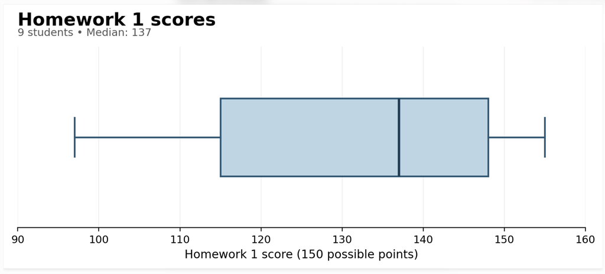

## HW1 + Midterm Scores

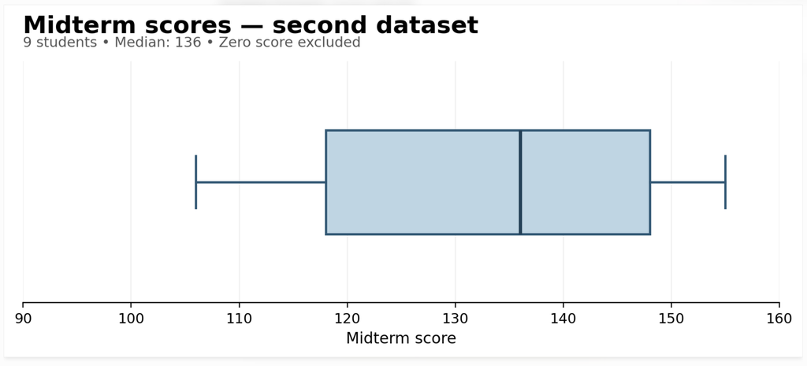

## What can a sample tell us?

### From Description and Exploration to Inference

> What is Statistical Inference?

**Making conclusions about a population using information in a sample!**

- How long do residents in a city spend their time commuting?
  - Making estimates about a population parameter.
- Does providing shade in an area reduce exposure to heat?
  - Hypothesis testing : testing research claims
    - Is what we observe due to what we claim?
    - Or is it due to random chance/ natural variability in sampling?

## A city has a question

> How long do residents spend commuting?

We can measure everyone, or learn from a sample.

**Inference uses data and a probability model to learn about an unknown quantity and quantify uncertainty.**

## A result needs a reference

**Survey:** our sample mean commute is 25 minutes. How precisely does it estimate the population mean?

**Experiment:** shaded plots average 4°C cooler. Could random assignment produce a difference this large if shade had no effect?

## Two different sources of variability

| Random sampling | Random assignment |
| --- | --- |
| Which people enter the survey? | Which plots receive shade? |
| A different sample can give a different mean. | A different allocation can give a different group difference. |

Each analysis must mimic the source of randomness in its study.

## Activity 1 · The commute lottery

**A toy city has six equally common commute times:**

5, 10, 15, 20, 25, 30 minutes

Its population mean is **17.5 minutes**.

Prediction: will everyone obtain a sample mean of 17.5?

## Five draws make one sample

```r
set.seed(student_seed)
my_sample <- city |>
  rep_sample_n(size = 5, reps = 1, replace = TRUE)
my_sample
my_sample |>
  summarise(sample_mean = mean(minutes), .groups = "drop")
```

Inspect five observations. Add **one mean** to the whiteboard.

## The population stays the same

**The people drawn change. Their mean changes.**

That movement from sample to sample is **sampling variability**.

The distribution of means from repeated samples is a **sampling distribution**.

Its standard deviation is the **standard error**.

## What would 20 draws change?

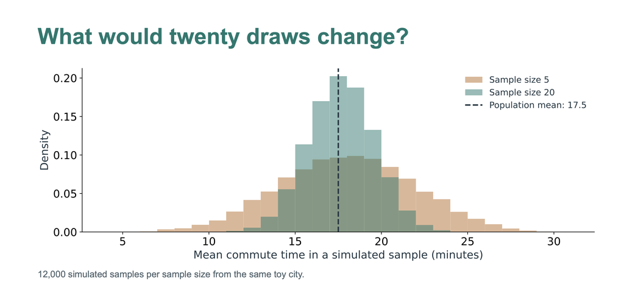

## The same lottery in R

```r
library(tidyverse)
library(infer)
city <- tibble(minutes = seq(5, 30, by = 5))
set.seed(student_seed + 1)
sampling_5 <- city |>
  rep_sample_n(size = 5, reps = 2000, replace = TRUE) |>
  summarise(stat = mean(minutes), .groups = "drop")
```

Change `size = 5` to `size = 20` and compare the spread.

## Activity 2 · Does shade cool a surface?

A fictional experiment uses **20 separated, comparable plots**.

Random assignment gives 10 plots shade cloth and 10 plots sun. Measure surface temperature after one hour.

**Question:** does shade change surface temperature?

## The observed difference

| Shade: 10 plots | Sun: 10 plots |
| --- | --- |
| 28, 30, 31, 32, 33 | 32, 34, 35, 36, 37 |
| 34, 35, 36, 38, 39 | 38, 39, 40, 42, 43 |
| **Mean = 33.6°C** | **Mean = 37.6°C** |

**D = mean(shade) − mean(sun) = −4.0°C**

## A null model gives us a comparison

**Null hypothesis:** shade has no effect on any plot.

Under this sharp null, each plot keeps its observed temperature regardless of its assignment.

**Alternative:** shade changes temperature for at least some plots.

We will use differences in group means to detect a change.

## Everyone becomes a randomization machine

```r
set.seed(student_seed + 10)
one_shuffle <- temperature |>
  specify(temp_c ~ treatment) |>
  hypothesize(null = "independence") |>
  generate(reps = 1, type = "permute")
one_shuffle
```

Inspect the shuffled data before calculating a difference.

## What does one dot mean here?

```r
one_shuffle |>
  calculate(stat = "diff in means",
            order = c("shade", "sun"))
```

Add **one difference** to the board.

One dot represents one possible assignment under the null.

## A two-sided p-value counts both tails

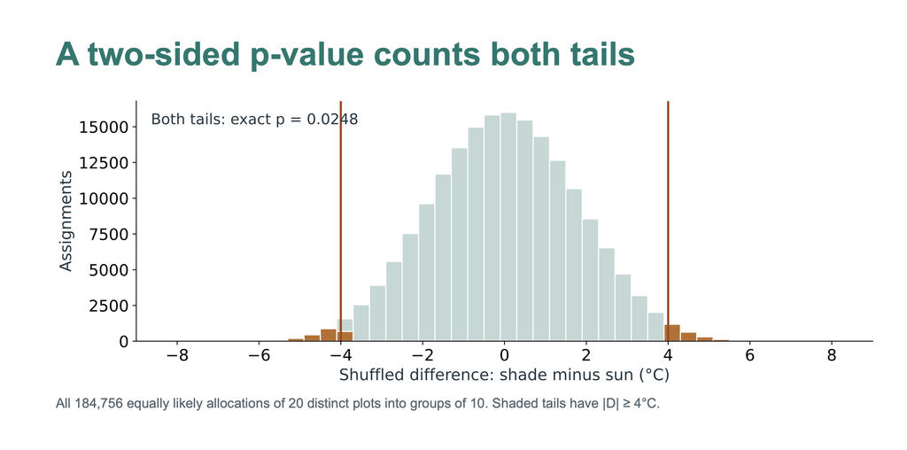

## What does the p-value say?

**Assuming the null model and study assumptions hold**, the p-value is the probability of obtaining a test statistic at least as extreme as the observed statistic.

For this test, “as extreme” means **D ≤ −4 or D ≥ +4**.

A smaller p-value indicates greater incompatibility with the null model.

## The shuffle in infer

```r
set.seed(student_seed + 12)
null_dist <- temperature |>
  specify(temp_c ~ treatment) |>
  hypothesize(null = "independence") |>
  generate(reps = 10000, type = "permute") |>
  calculate(stat = "diff in means",
            order = c("shade", "sun"))
```

The student script defines `temperature` and calculates `observed`.

## The computer counts the tails

```r
null_dist |>
  get_p_value(obs_stat = observed, direction = "both")

visualize(null_dist) +
  shade_p_value(obs_stat = observed, direction = "both")
```

10,000 shuffles improve simulation precision.

They do **not** increase the experiment’s sample size.

## Evidence, magnitude, and decisions

**Observed difference:** shade plots average 4°C cooler.

**Evidence:** the randomization test assesses compatibility with no effect.

**Decision rule:** with α = 0.05 set in advance, reject when p ≤ 0.05.

Would 0.049 and 0.051 justify very different scientific stories?

## Activity 3 · How long is the commute?

A **separate fictional survey** takes a simple random sample of eight residents from a large city population.

10, 15, 15, 20, 25, 30, 35, 50 minutes

**Sample mean = 25 minutes.**

How much uncertainty surrounds that estimate?

## The population is out of reach

We would like many new samples from the city.

We have only **one sample**.

The bootstrap uses that sample as an approximation to the population and resamples it to estimate sampling variability.

## Everyone makes a bootstrap sample

```r
set.seed(student_seed + 20)
one_bootstrap <- commute |>
  specify(response = minutes) |>
  generate(reps = 1, type = "bootstrap")
one_bootstrap
one_bootstrap |> calculate(stat = "mean")
```

Inspect eight draws. Add **one mean** to a new board axis.

## Why does replacement matter?

Without replacement, selecting all eight respondents returns the same eight observations every time.

**Every mean would equal 25.**

`type = "bootstrap"` samples with replacement, allowing the composition and mean to vary while keeping n = 8.

## Bootstrapping in infer

```r
set.seed(student_seed + 22)
boot_dist <- commute |>
  specify(response = minutes) |>
  generate(reps = 10000, type = "bootstrap") |>
  calculate(stat = "mean")

ci_95 <- boot_dist |>
  get_confidence_interval(level = 0.95, type = "percentile")
```

No null hypothesis is imposed in this estimation workflow.

## The middle 95% gives an interval

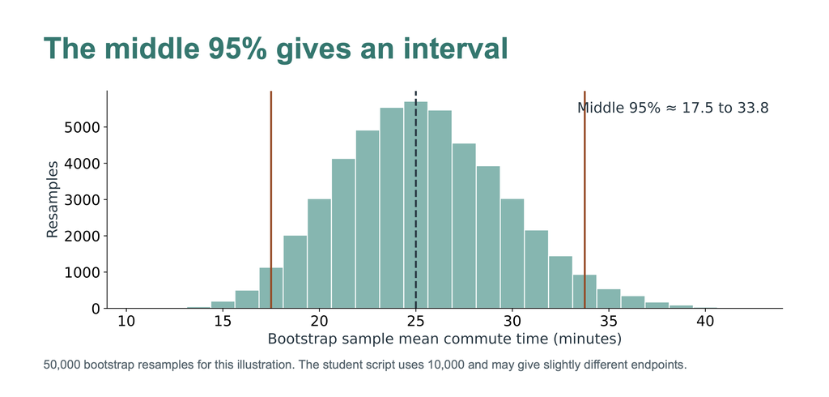

## What does “95% confidence” mean?

**It describes the interval-making procedure.**

Across repeated random samples, a well-calibrated 95% procedure produces intervals that contain the fixed population mean about 95% of the time.

Our computed interval either contains that mean or misses it. We do not know which.

## Repeated intervals, one population mean

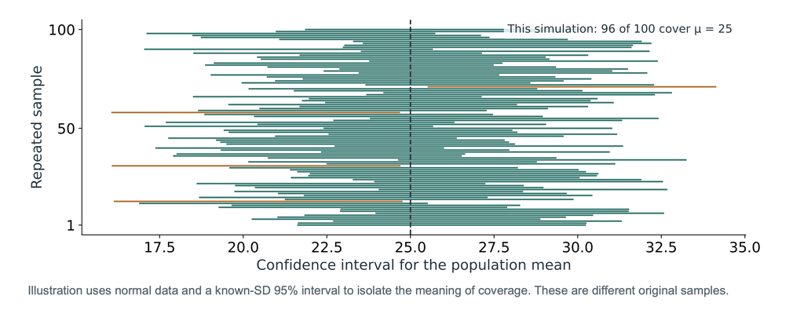

## What a confidence interval does not say

“95% of residents commute for a time inside this interval.”

“95% of future sample means must fall inside this interval.”

“There is a 95% frequentist probability that the fixed mean lies in this computed interval.”

**Each statement misinterprets the interval.**

## Two simulations, two questions

|  | Shuffling | Bootstrapping |
| --- | --- | --- |
| Question | Is the statistic unusual under a null model? | How variable is our estimate? |
| Action today | Reassign outcomes to groups | Draw rows with replacement |
| What stays fixed? | Values and group sizes | Original sample and resample size |
| Typical center | Null value: 0 here | Observed estimate: 25 here |
| Output today | p-value | Confidence interval |

## A geographic conclusion needs a design

**Random sampling** supports inference to the sampling population.

**Random assignment** supports a causal comparison for experimental units.

Nearby sites, repeated observations, and clustered households may require different resampling units.

More resamples cannot repair a biased sample.

## Three-minute exit ticket

1. What does one dot represent in each of our three distributions?
2. Why does shuffling preserve each outcome once while bootstrapping allows repeated observations?
3. A p-value is 0.03. Write one valid interpretation.
4. What changes when we increase resamples from 1,000 to 10,000? What changes when we increase sample size?

## After class

**Read:** IMS Chapters 11, 12, 13, 14, 15.

**Practice:** Lesson on foundation of inference

**Use the worksheet:** change sample size, resample count, and confidence level. Predict each result before running it.